# The Bayesian GGE (SREG) model

Muhammad Yaseen

2026-11-09

# 1 Abstract

The GGE model, also called the sites regression (SREG) model, puts the genotype main effects into the bilinear terms. Its biplot shows directly which genotype wins where (Yan et al. 2000). `bayes_ammi(.model = "GGE")` fits it by the Gibbs sampler of Perez-Elizalde et al. (2012), and `bam_winners()` turns the draws into probabilities that each genotype wins in each environment.

# 2 Model

$$y_{ijl} = \mu + \delta_j + \sum_{k=1}^{K}\lambda_k\alpha_{ik}\gamma_{jk} + e_{ijl}.$$

There are no genotype effects $\tau_i$. The genotype scores $\va_k$ still sum to zero, but the environment scores $\vg_k$ are only orthonormal: they need not sum to zero, because the bilinear terms now carry the genotype main effects. The conditional of $\vg_k$ is therefore von Mises-Fisher on the sphere orthogonal to the other environment vectors only.

# 3 The fit

```r
fg <-
  bayes_ammi(
      .data   = Maiz
    , .y      = y
    , .gen    = entry
    , .env    = site
    , .rep    = rep
    , .nIter  = 3000
    , .k      = 2
    , .burnin = 500
    , .thin   = 1
    , .chains = 2
    , .priors = bam_priors(
          mu_mean     = 0
        , mu_var      = 1e+8
        , tau_mean    = 0
        , tau_var     = 1e+8
        , delta_mean  = 0
        , delta_var   = 1e+8
        , lambda_mean = 0
        , lambda_var  = 1e+8
        , nu          = 1
        , s2          = NULL
        )
    , .level  = 0.95
    , .seed   = 5
    , .align  = TRUE
    , .model  = "GGE"
    , .het    = FALSE
    , .waic   = TRUE
    )
fg
```

```
Bayesian GGE with 2 multiplicative term(s): 9 genotypes, 20 environments, 4 replicates
2 chain(s) x 3000 kept draws (iterations 3000 after a burn-in of 500, thinning 1); 1.4 s

Posterior means, standard deviations and 95% HPD intervals
    parameter      mean      sd      lower     upper   ess   rhat
       <char>     <num>   <num>      <num>     <num> <num>  <num>
 1:        mu   4858.20    32.2  4.792e+03   4917.83  5657 1.0003
 2:    sigma2 769781.75 43525.5  6.875e+05 857210.04  3455 0.9999
 3:  delta[1]  -1244.17   140.1 -1.505e+03   -956.56  6000 1.0000
 4:  delta[2]   -647.71   141.1 -9.066e+02   -352.29  5998 0.9999
 5:  delta[3]    246.91   142.6 -2.923e+01    532.31  6000 1.0007
 6:  delta[4]    372.56   142.0  8.985e+01    645.45  6193 1.0000
 7:  delta[5]     93.71   142.9 -2.020e+02    358.62  6000 1.0003
 8:  delta[6]   1445.53   142.2  1.175e+03   1728.42  5680 1.0011
 9:  delta[7]  -1628.11   142.3 -1.901e+03  -1346.60  6425 0.9999
10:  delta[8]   -824.93   142.6 -1.102e+03   -540.44  6000 1.0002
11:  delta[9]    112.77   144.8 -1.695e+02    392.32  6000 1.0000
12: delta[10]  -1924.00   140.9 -2.186e+03  -1641.97  6000 1.0003
13: delta[11]    449.78   141.8  1.852e+02    736.33  6598 1.0005
14: delta[12]   2655.65   144.5  2.385e+03   2947.44  6000 1.0004
15: delta[13]   1471.47   143.8  1.202e+03   1765.02  6000 1.0000
16: delta[14]   1193.27   143.7  9.162e+02   1478.64  6000 1.0002
17: delta[15]    190.91   139.9 -8.342e+01    464.65  6000 1.0008
18: delta[16]    547.78   141.7  2.728e+02    827.19  6163 0.9998
19: delta[17]     20.31   141.3 -2.489e+02    306.13  6213 1.0001
20: delta[18]   -305.36   144.3 -6.044e+02    -28.03  6000 1.0004
21: delta[19]  -2207.73   141.1 -2.472e+03  -1925.45  6000 1.0011
22: delta[20]    -18.63   141.7 -2.852e+02    262.87  6420 1.0001
23: lambda[1]   6893.58   445.4  6.057e+03   7808.55  5187 1.0007
24: lambda[2]   1608.47   757.7  2.211e-02   2768.36   731 1.0004
    parameter      mean      sd      lower     upper   ess   rhat
       <char>     <num>   <num>      <num>     <num> <num>  <num>

Scores of the bilinear terms: x$summary (blocks alpha, gamma); biplot coordinates: x$scores

Sources: Crossa et al. (2011); Perez-Elizalde et al. (2012); Yan et al. (2000);
Spiegelhalter et al. (2002); Watanabe (2010). Full references: bam_cite(x).
```

# 4 The GGE biplot with HPD regions

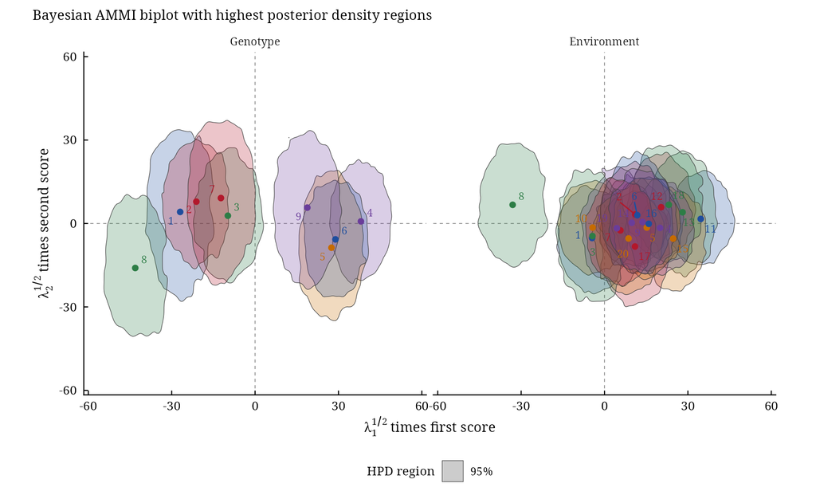

```r
bg <-
  biplots(
      model         = fg
    , burnin        = 0
    , thin          = 1
    , pb            = 0.05
    , plot_stable   = TRUE
    , plot_unstable = TRUE
    , ncolors       = 5
    , .which        = "both"
    , .grid         = 100
    )
bg$biplot
```

On a GGE biplot the first axis mostly reflects the genotype means. A genotype region that lies away from the origin on the first axis therefore marks a genotype that is above or below average, rather than one with interaction.

# 5 Which genotype wins where

The winner of environment $j$ is the genotype with the largest $\eta_{ij}$. Over the draws, $P_{ij}$ is the posterior probability that genotype $i$ wins in environment $j$:

```r
wg <-
  bam_winners(
      fit           = fg
    , higher_better = TRUE
    )
wg
```

```
Which genotype wins where: posterior probabilities (higher is better)

       Env Winner Probability Second Probability2
    <char> <char>       <num> <char>        <num>
 1:      1      8      0.7023      1      0.06750
 2:      2      4      0.6522      6      0.13783
 3:      3      8      0.5707      1      0.13817
 4:      4      4      0.7202      6      0.13767
 5:      5      4      0.7047      6      0.13600
 6:      6      4      0.6123      5      0.16567
 7:      7      4      0.3880      5      0.20483
 8:      8      8      0.7293      1      0.19900
 9:      9      4      0.6282      5      0.16450
10:     10      8      0.6008      1      0.11050
11:     11      4      0.8387      6      0.09267
12:     12      4      0.7837      6      0.09067
13:     13      4      0.7732      6      0.10683
14:     14      4      0.6215      5      0.15300
15:     15      4      0.6767      5      0.17750
16:     16      4      0.7332      5      0.13333
17:     17      4      0.4532      5      0.27467
18:     18      4      0.7932      6      0.10217
19:     19      4      0.3423      5      0.18467
20:     20      4      0.4505      5      0.28317
       Env Winner Probability Second Probability2
    <char> <char>       <num> <char>        <num>

Groups of environments with the same most probable winner
   Winner                                             Environments     n
   <char>                                                   <char> <int>
1:      4 2, 4, 5, 6, 7, 9, 11, 12, 13, 14, 15, 16, 17, 18, 19, 20    16
2:      8                                              1, 3, 8, 10     4
   mean_probability
              <num>
1:           0.6357
2:           0.6508

Sources: Yan et al. (2000). Full references: bam_cite(x).
```

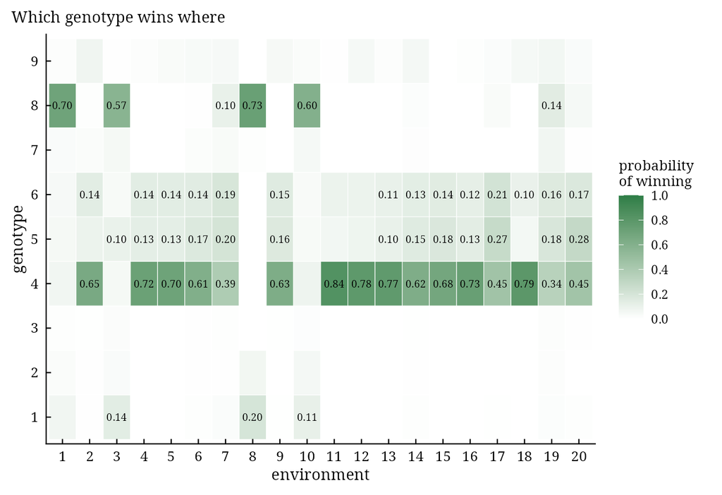

```r
plot(x = wg)
```

The environments split into 2 groups by their most probable winner. In a GGE analysis such groups are the candidates for mega-environments. The probability column shows how sure each assignment is: a winner with probability near one half has a close rival, given in `Second`.

# 6 AMMI or GGE?

The two models describe the same cell means with different constraints, so they fit almost equally well:

```r
fa <-
  bayes_ammi(
      .data   = Maiz
    , .y      = y
    , .gen    = entry
    , .env    = site
    , .rep    = rep
    , .nIter  = 3000
    , .k      = 2
    , .burnin = 500
    , .thin   = 1
    , .chains = 2
    , .priors = bam_priors(
          mu_mean     = 0
        , mu_var      = 1e+8
        , tau_mean    = 0
        , tau_var     = 1e+8
        , delta_mean  = 0
        , delta_var   = 1e+8
        , lambda_mean = 0
        , lambda_var  = 1e+8
        , nu          = 1
        , s2          = NULL
        )
    , .level  = 0.95
    , .seed   = 5
    , .align  = TRUE
    , .model  = "AMMI"
    , .het    = FALSE
    , .waic   = TRUE
    )
bam_compare(
    AMMI = fa
  , GGE  = fg
  )
```

```
Comparison of Bayesian models (smaller is better)

    model terms variances      DIC      pD     WAIC  p_waic      se
   <char> <int>    <char>    <num>   <num>    <num>   <num>   <num>
1:    GGE     2    common 11861.15 60.7946 11863.52 58.8784 44.4921
2:   AMMI     2    common 11862.70 67.8688 11866.51 65.9871 44.2345
   lambda_last_lower lambda_last_mean  dWAIC dWAIC_se
               <num>            <num>  <num>    <num>
1:            0.0221         1608.475 0.0000   0.0000
2:            1.4208         1647.706 2.9899   7.3096

Sources: Spiegelhalter et al. (2002); Watanabe (2010); Vehtari et al. (2017).
Full references: bam_cite(x).
```

Choose AMMI to study interaction separately from the genotype means, and GGE to study which genotype wins where.

# 7 Interpretation

```r
bam_interpret(
    x             = wg
  , higher_better = TRUE
  , top           = 5
  )
```

```
Which genotype wins where

2 genotype(s) are the most probable winners; 16 of 20 environments have a
winner with probability of at least 0.5.

Findings:
- 4 wins most probably in 2, 4, 5, 6, 7, 9, 11, 12, 13, 14, 15, 16, 17, 18,
  19, 20 (mean probability 0.64).
- 8 wins most probably in 1, 3, 8, 10 (mean probability 0.65).
- No clear winner (largest probability below 0.5) in: 7, 17, 19 and 20.

Recommendations:
- Several winners: the environments may form mega-environments; confirm the
  grouping over years.

Cautions:
- A probability of winning near 1/G means the genotypes cannot be told apart
  in that environment.

Sources:
- Yan, W., Hunt, L. A., Sheng, Q. and Szlavnics, Z. (2000). Cultivar
  evaluation and mega-environment investigation based on the GGE biplot. Crop
  Science, 40(3), 597-605. doi:10.2135/cropsci2000.403597x
```

# 8 References

Perez-Elizalde, S., Jarquin, D. and Crossa, J. (2012). A general Bayesian estimation method of linear-bilinear models applied to plant breeding trials with genotype x environment interaction. *Journal of Agricultural, Biological, and Environmental Statistics*, 17, 15–37. doi:10.1007/s13253-011-0063-9

Yan, W., Hunt, L. A., Sheng, Q. and Szlavnics, Z. (2000). Cultivar evaluation and mega-environment investigation based on the GGE biplot. *Crop Science*, 40(3), 597–605.

Crossa, J., Perez-Elizalde, S., Jarquin, D., Cotes, J. M., Viele, K., Liu, G. and Cornelius, P. L. (2011). Bayesian estimation of the additive main effects and multiplicative interaction model. *Crop Science*, 51(4), 1458–1469. doi:10.2135/cropsci2010.06.0343

Wood, A. T. A. (1994). Simulation of the von Mises Fisher distribution. *Communications in Statistics - Simulation and Computation*, 23(1), 157–164.